# Preliminary study: test scenarios for ethics scale

Julius Fenn

03.03.2022

# 1 Scenario Texts

1. Stratospheric Aerosol Injection descriptive version (pure description of SAI)
2. Stratospheric Aerosol Injection narrative version (an actor named Charlie experiences the deployment of SAI)
3. Nano-Pat-Parka (scenario text developed within livmats using basic attributes)
4. Social Robots (scenario text developed after identifying *key factors*)

> Scenario texts 2, 3, and 4 are for the development of an Empirical Ethics Scale within livMatS (sample from the USA, as part of a collaboration with Penn State University)

and,

> Scenario text 1 is for the SAI study in collaboration with Andreas (sample from England)

The **goal of these pilot studies** is to have scenario texts that are as neutral and understandable as possible (2.), to reconfirm understanding (3.), and to have the highest possible ambiguity measured through moral intensity (4.), as well as a “baseline affect” (measured using *affective imagery technique*) (5.).

# 2 Overall

```r
nrow(questionnaire_NanoPat)
```

```
## [1] 27
```

```r
nrow(questionnaire_SAIdes)
```

```
## [1] 30
```

```r
nrow(questionnaire_SAInar)
```

```
## [1] 30
```

```r
nrow(questionnaire_SocialRobots)
```

```
## [1] 30
```

```r
nrow(questionnaire_NanoPat) +
nrow(questionnaire_SAIdes) +
nrow(questionnaire_SAInar) +
nrow(questionnaire_SocialRobots)
```

```
## [1] 117
```

# 3 Clarity, Bias in the Scenario Texts

> Scenario texts for SAI are too positive.

> Scenario text for Nano-Pat-Parka is too positive, as well as possible comprehension problems.

> Scenario text for Social Robots is generally too negative.

**Scenario Texts for SAI**

The scenario texts for SAI are written too positively according to 20% of the surveyed individuals (Bias):

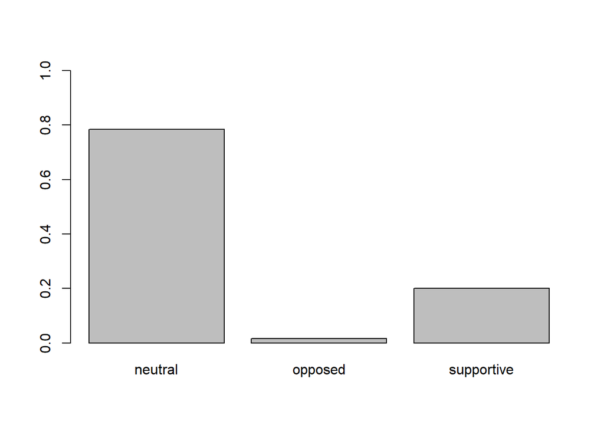

```
##
##    neutral    opposed supportive
##         78          2         20
```

The scenario texts for SAI are understandable (only 7% had problems):

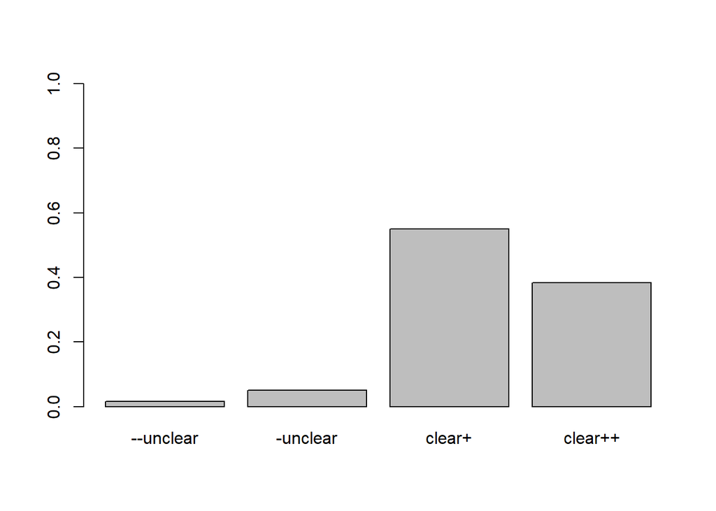

```
##
## --unclear  -unclear    clear+   clear++
##         2         5        55        38
```

**Scenario Text for Nano-Pat-Parka**

The scenario text for Nano-Pat-Parka is written too positively according to 22% of the surveyed individuals (Bias):

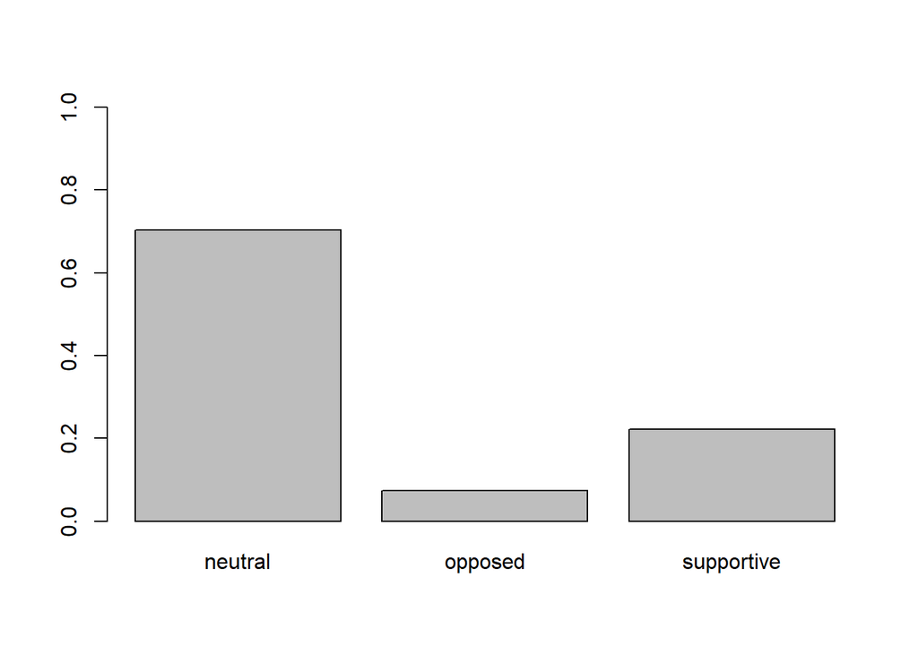

```
##
##    neutral    opposed supportive
##         70          7         22
```

The scenario text for Nano-Pat-Parka is largely understandable (however, 19% had problems):

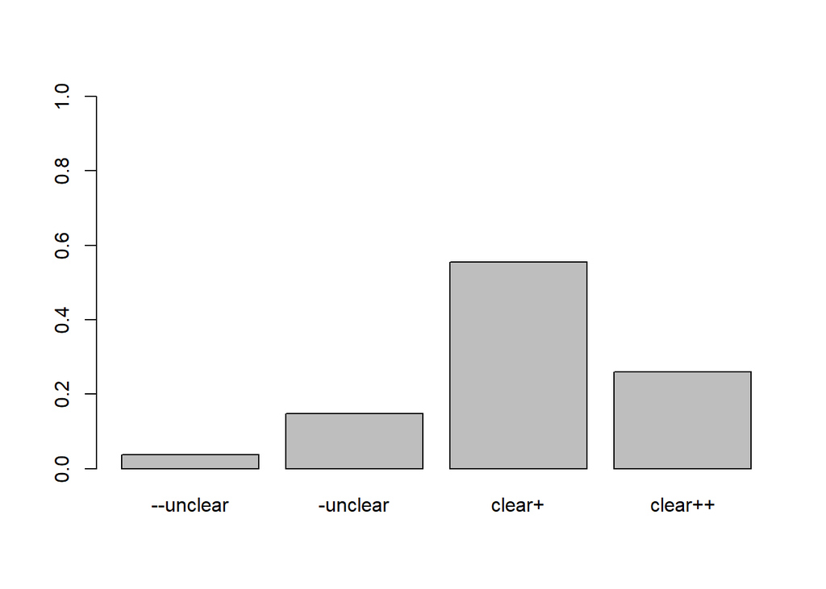

```
##
## --unclear  -unclear    clear+   clear++
##         4        15        56        26
```

Some individuals have written comments about this issue:

```
## [1] "it did not explain the actual technology in a way that a normal person can interpret"
## [2] "I do not know why but it was dumb "
## [3] "it was hard to understand exactly what they were saying and what the effects would be"
## [4] "not many details given, no clear picture of what this jacket does or what wearing it looks like"
## [5] "I was not given enough details"
```

**Scenario Text for Social Robots**

The scenario text for Social Robots are written too negatively according to 20% of the surveyed individuals (Bias):

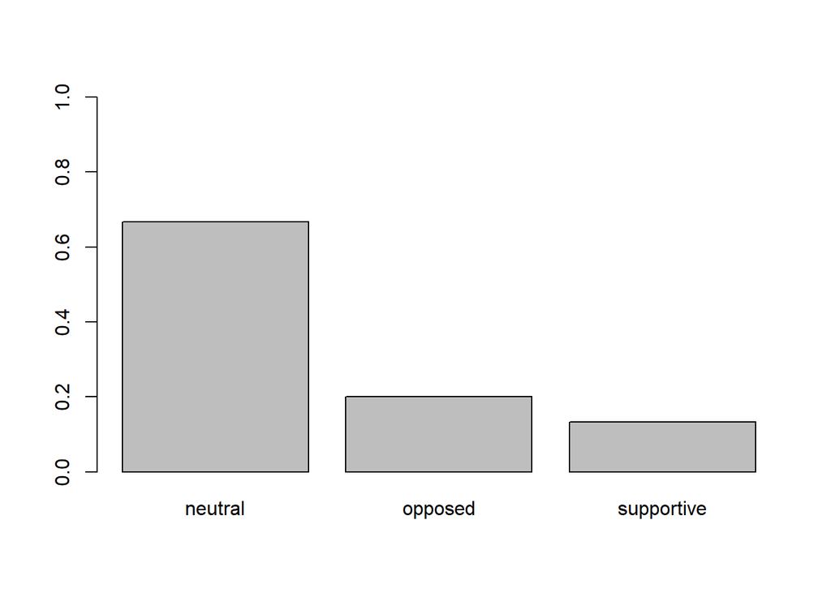

```
##
##    neutral    opposed supportive
##         67         20         13
```

The scenario text for Social Robots is largely understandable (only 3% had problems):

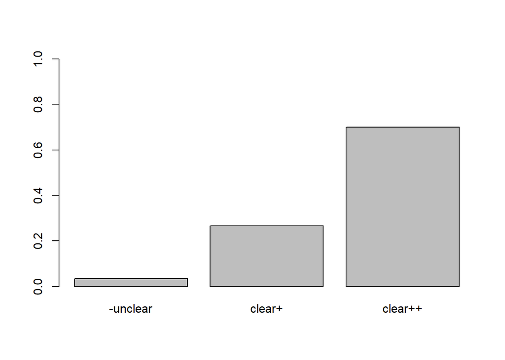

```
##
## -unclear   clear+  clear++
##        3       27       70
```

**Question** from Mercer, Keith, & Sharp, 2011

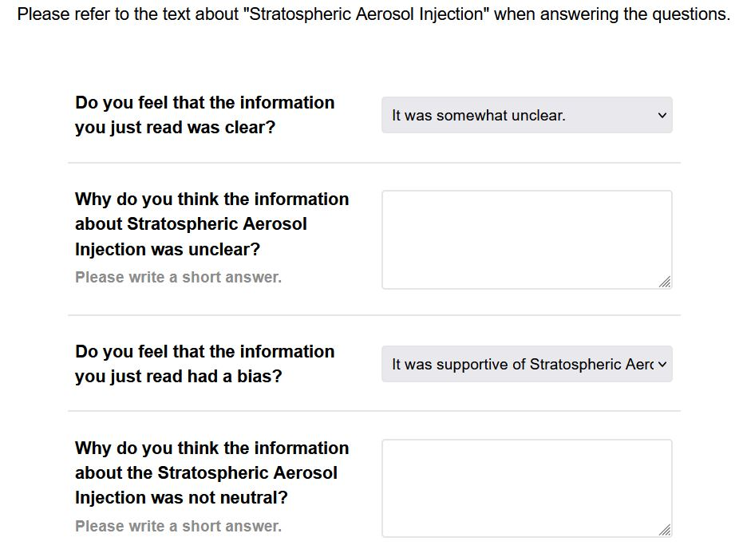

# 4 Clarification of Understanding

> The scenario text for Nano-Pat-Parka resulted in highly varying answers regarding the understanding of the text.

**Scenario Texts for SAI**

*Questions are below.* Here only the first 4 responses are displayed. A large portion (> 95%) understood the basic principles of SAI, but not always the mechanism.

| undSAIgeneral | undSAIgoal | undSAIhow |
| --- | --- | --- |
| It releases sulfur particles in the atmosphere | Stop the global temperature from increasing | By releasing sulfur particles back to the sun |
| this is to release sulfur high in the earths atmosphere to block some of the sun rays | to stop the earth from getting warmer | it is not clear if this will work |
| Sending sulfur particles into space to reflect sunrays back to prevent them reaching earth. | To mitigate the heating up of the planet but won’t address the underlying cause of warming. | By releasing them via aircraft. |
| particles, in this case sulphur, can be released high in to the atmosphere in regions where the sun’s radiation penetrates the stratosphere in particular. These particles could be released by plane | The hope is that it will help cool the earth | The sulphur particles would reflect the radiation from the sun rather than it hitting the earth and warming it, this is based on evidence from volcanoes which release a lot of sulphur particles in to … |

**Scenario Text for Nano-Pat-Parka**

Here only the first 4 answers are displayed. Responses were highly varied.

| undNanoPatGeneral | undNanoPatGoal | undNanoPatHow |
| --- | --- | --- |
| It is a outer wear device that detects changes in the clilmate and adjusts appropriately. | A multi-purpose device that can be used in many situations | Sensing internal and external changes |
| it is an atuonimous ecosystem which resides within the clothing. it is poisonous and needs a lot of maintenance | it can self regulate on its own with no used input. it has the ability to learn in different climates | it learns from different climates and the person wearing the item. |
| It is a jacket with enhanced, “smart” capabilities that make it useful for humans to wear in a changing and challenging climate. | It helps keep wearers safe. | It is luminous, can use GPS to help safety personal locate the wear, and can respond to local conditions to protect the wearer. |
| It is a jacket that adjusts to the outside temperatures with sensors. | It is supposed to keep you at a proper temperature and protect you from the elements | with sensors and tech it is able to adjust the jacket |

**Scenario Text for Social Robots**

Here only the first 4 answers are displayed.

| undSocialRobotsGeneral | undSocialRobotsPatGoal | undSocialRobotsPatHow |
| --- | --- | --- |
| An A.I. that is designed to learn behaviors of those around it and be able to reply with stereotypical answers while helping around the house with day to day tasks. | Day to day tasks around the house along with the parents started sending the robot to the kids to comfort them and make sure they were doing what they was suppose to when the parents weren’t home. | It accomplishes it by learning faces and memorizing names and learning to see when someone is sad or angry and the proper responses to give to them during that time. |
| It seems to be centered around the children. It acts as a companion and offers emotional support. | It can entertain and watch the children, and provide them a playmate. | It uses data to form impressions and then makes behavioral decisions. |
| AI robot | home tasks | AI, automatic knowledge built in rovbot |
| HomeMate was an AI that the family used to do everyday household things. | The robot was there to make lives easier for the family. | It did household tasks, greeted people, comforted the children, and served as a camera for parents to watch what was going on while they were away. |

**Question** designed by ourselves:

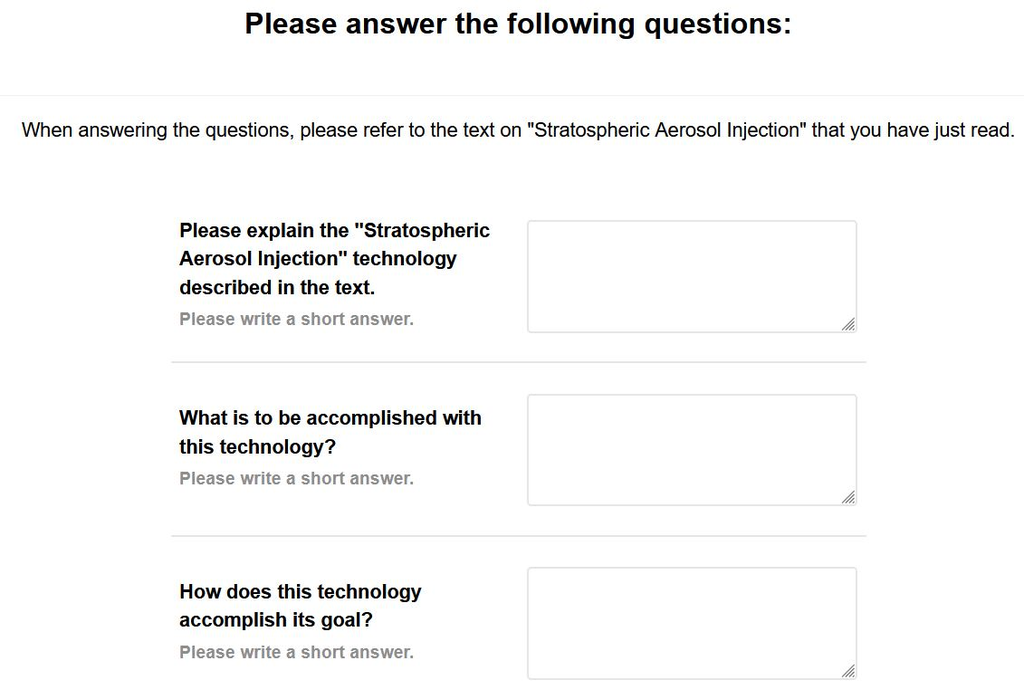

# 5 Confidence in Opinion

**Scenario Texts for SAI**

Confidence in the scenario texts for SAI is relatively mixed.

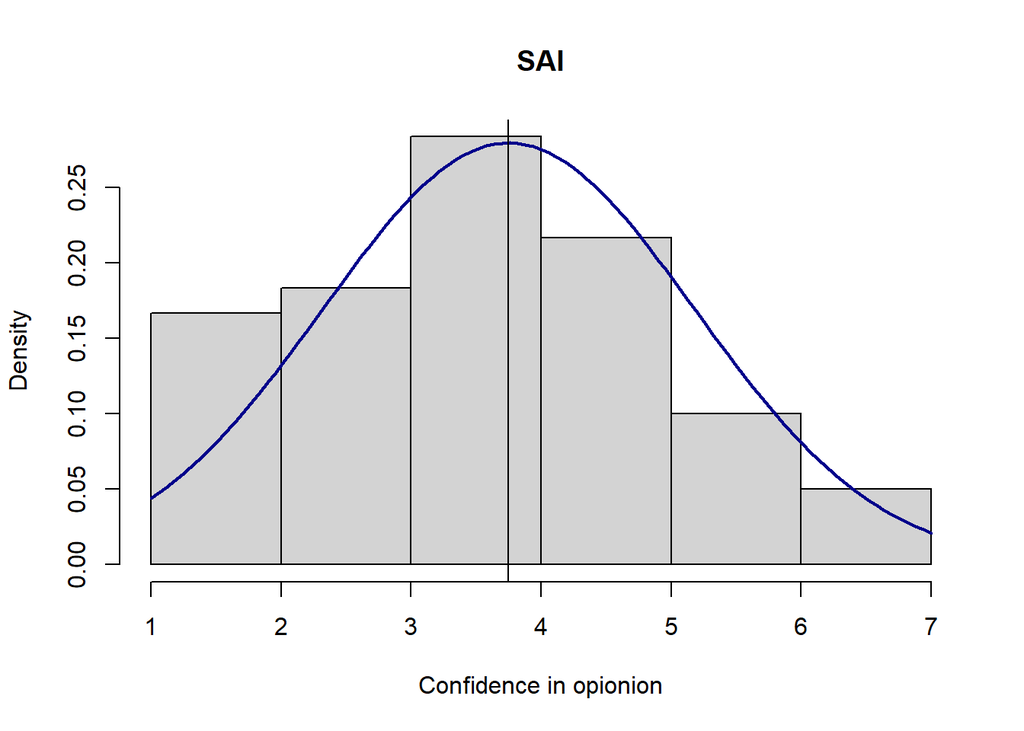

**Scenario Text for Nano-Pat-Parka**

Confidence in the scenario text for Nano-Pat-Parka is relatively high.

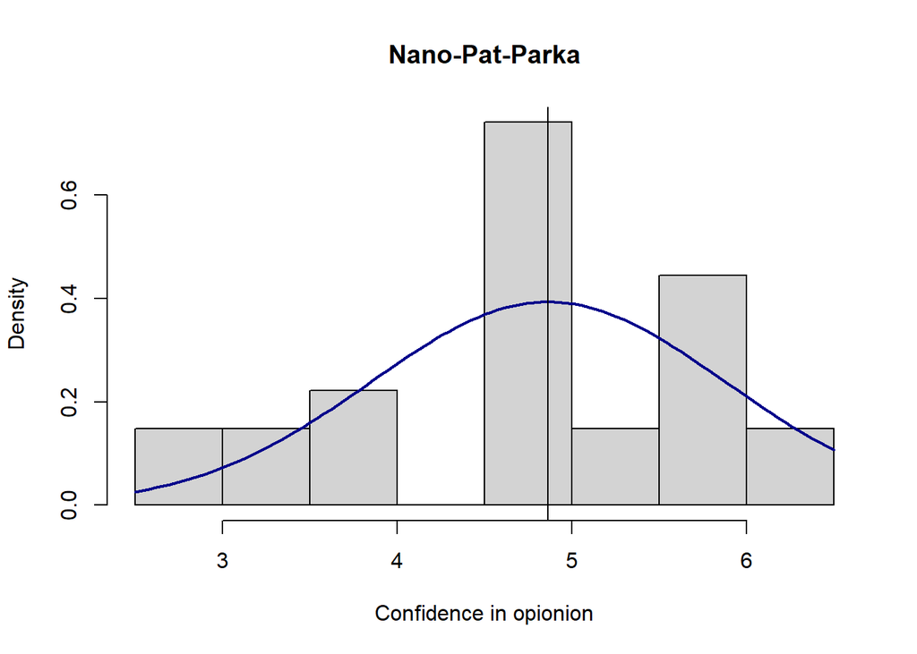

**Scenario Text for Social Robots** Confidence in the scenario texts for Social Robots is relatively high.

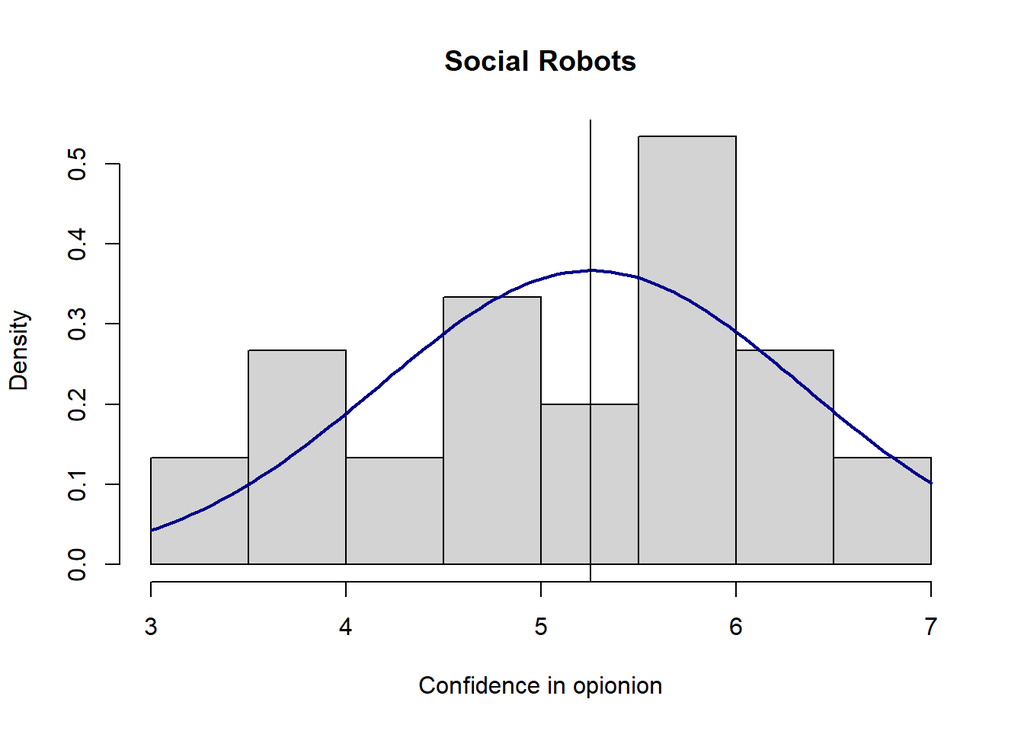

**Question** motivated by Mercer, Keith, & Sharp, 2011:

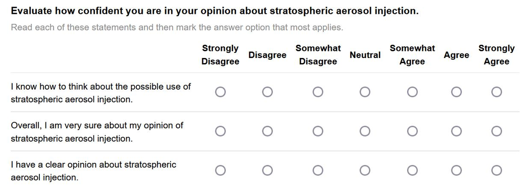

# 6 Ambivalence: Moral Intensity

**Scenario Texts for SAI**

*The scale ranges from 1 to 7, with a mean of 4.* SAI is perceived as relatively ambivalent in terms of moral intensity:

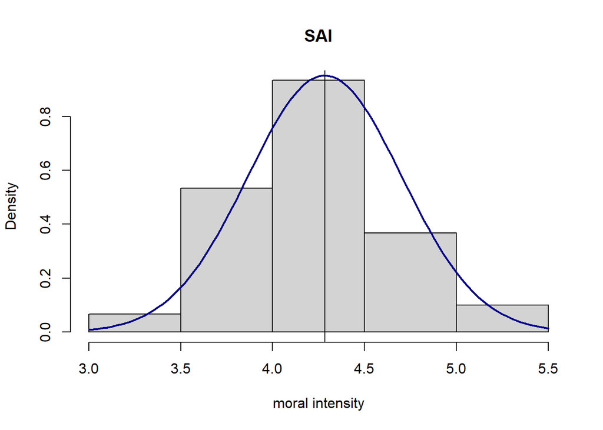

**Scenario Text for Nano-Pat-Parka**

Nano-Pat-Parka is perceived as relatively ambivalent in terms of moral intensity:

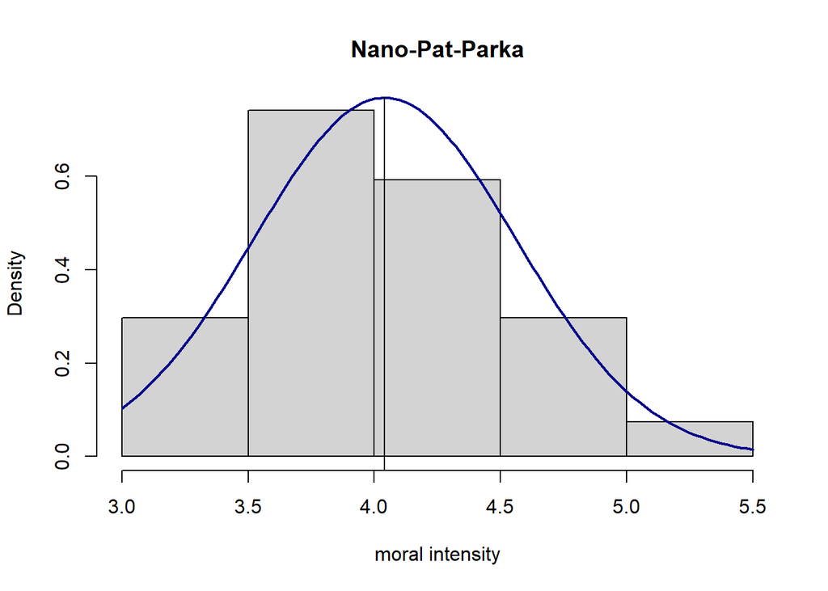

**Scenario Text for Social Robots**

Social Robots are perceived as relatively ambivalent in terms of moral intensity:

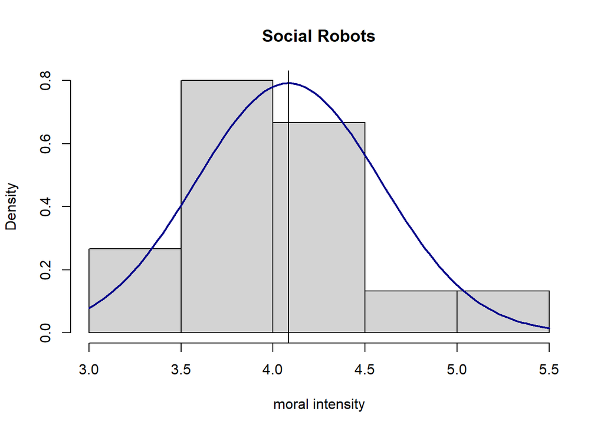

**Question** adapted from McMahon & Harvey, 2007:

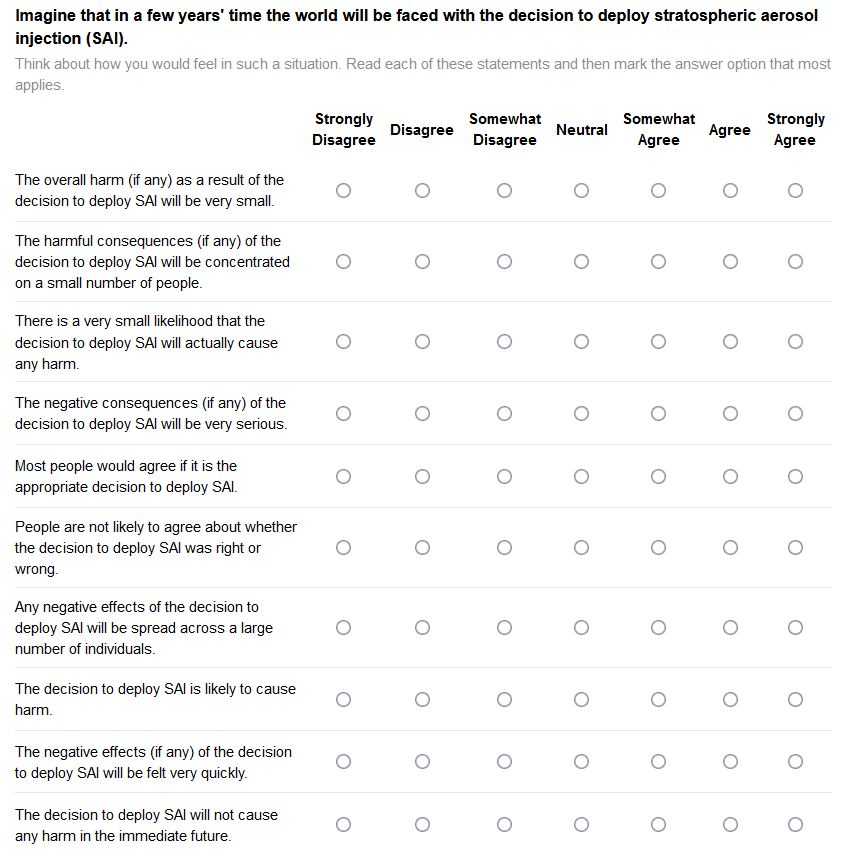

## 6.1 Narrative vs. Descriptive Text

The narrative text for SAI may be perceived as morally more intense (though not significant):

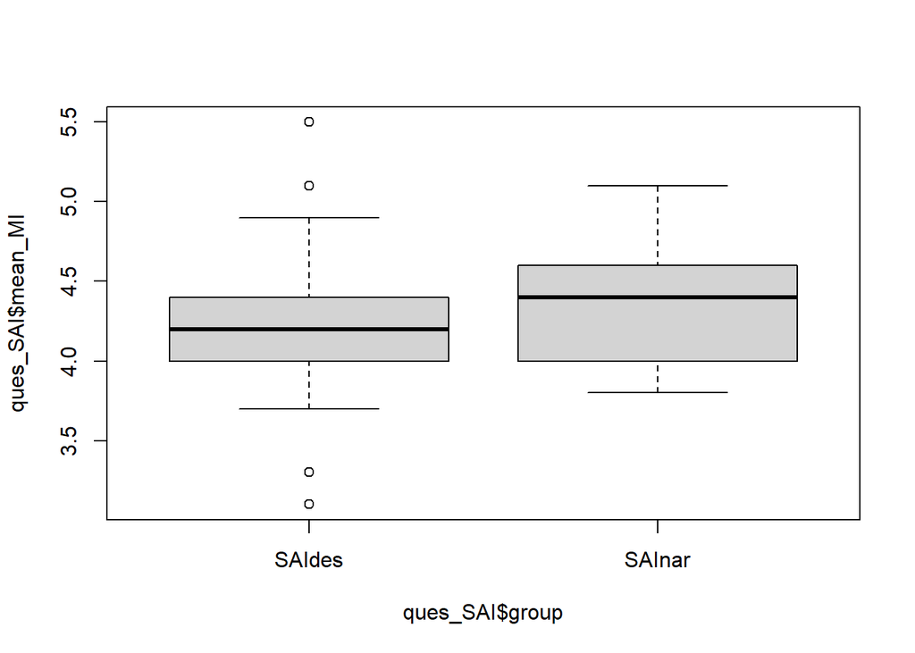

```
##
##  Welch Two Sample t-test
##
## data:  ques_SAI$mean_MI by ques_SAI$group
## t = -1.3013, df = 51.166, p-value = 0.199
## alternative hypothesis: true difference in means between group SAIdes and group SAInar is not equal to 0
## 95 percent confidence interval:
##  -0.35596342  0.07596342
## sample estimates:
## mean in group SAIdes mean in group SAInar
##             4.213333             4.353333
```

# 7 Ambivalence: Affective Imagery

**Scenario Texts for SAI**

*The scale ranges from 1 to 7, with a mean of 4.* SAI is perceived as relatively ambivalent in terms of the “baseline affect” regarding “Climate Engineering”:

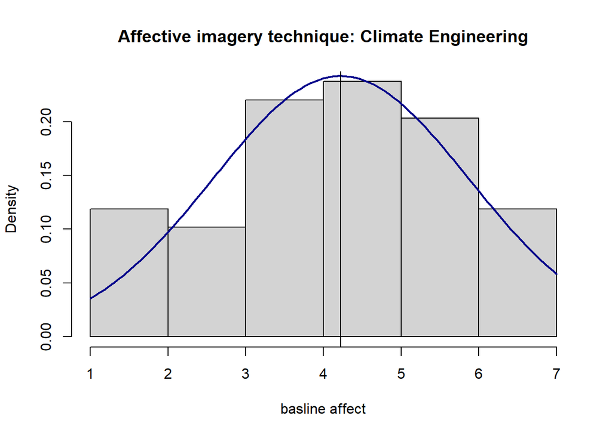

The first 10 associations to “Climate Engineering” are listed below, with each person providing a maximum of 5 associations (*cognitive component*), which are subsequently rated based on their affect (*affective component*). The mean of this affect from the given associations is shown in the histogram above.

| R1 | R2 | R3 | R4 | R5 |
| --- | --- | --- | --- | --- |
| technology | development | protection |  |  |
| weather | clouds | rain | sunny | tornardo |
| modelling | theory | research |  |  |
| wind turbines | coal | ocean cleaning | cloud seeding |  |
| change of climate | technology | temperature | science | weather |
| weather | global warming | earth friendly | sustainability | carbon neutral |
| green | renewable | future | global warming | change |
| americans | russians | governments | woke | media |
| altering nature | dangerous practises |  |  |  |
| Technology | Global warming | Uncertain | Meddling | Unproven |

**Scenario Text for Nano-Pat-Parka**

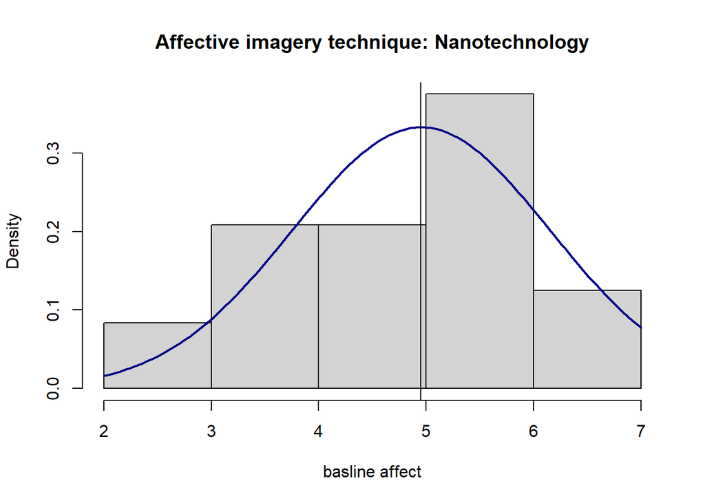

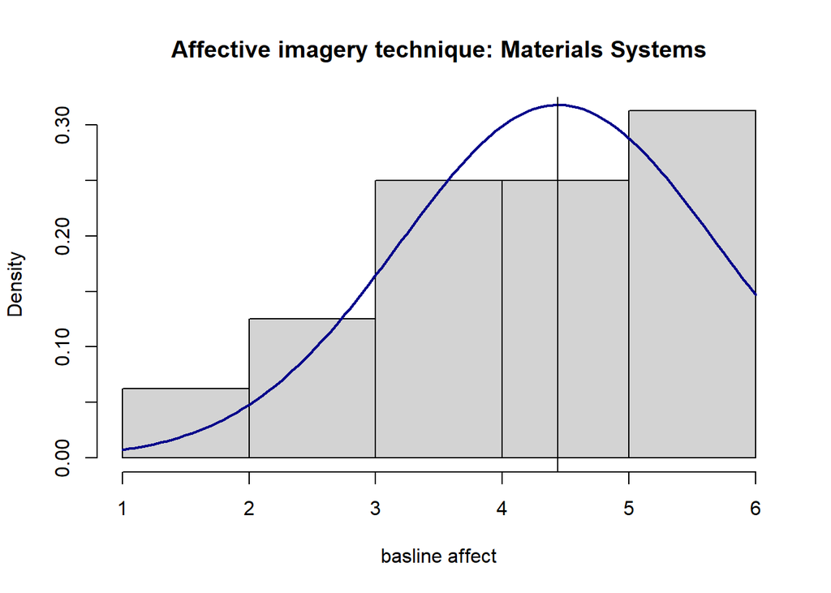

**Scenario Text for Social Robots**

Social Robots are perceived somewhat more positively in terms of the “baseline affect” regarding “Robotics”, though with high variance:

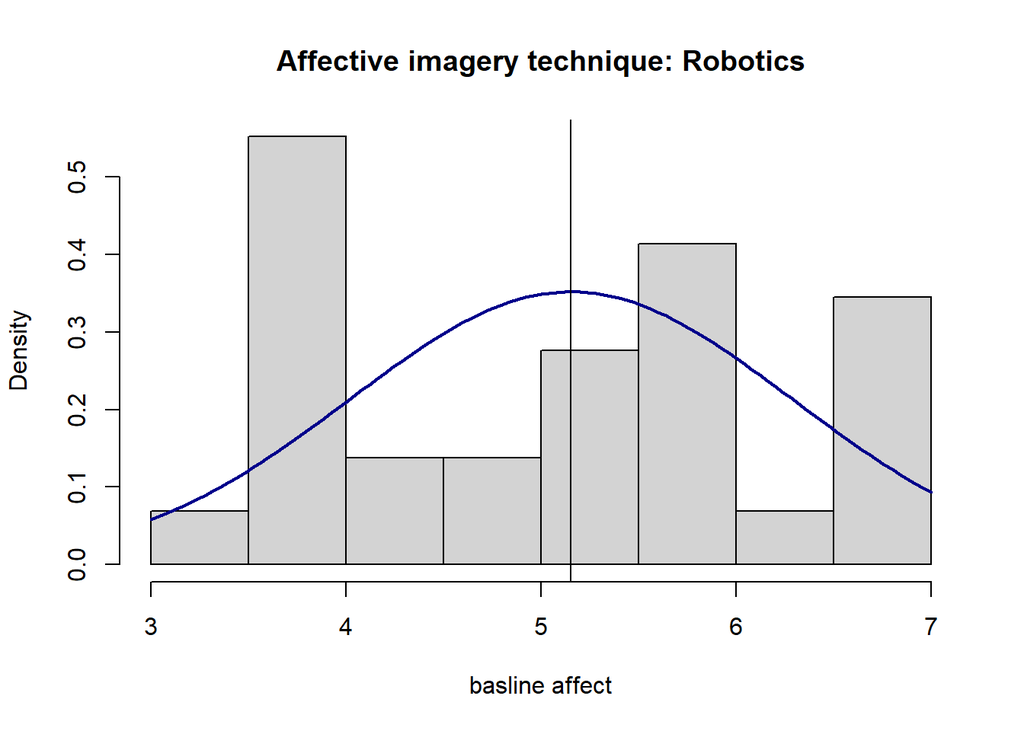

Social Robots are perceived ambivalently in terms of the “baseline affect” regarding “Social Robots”:

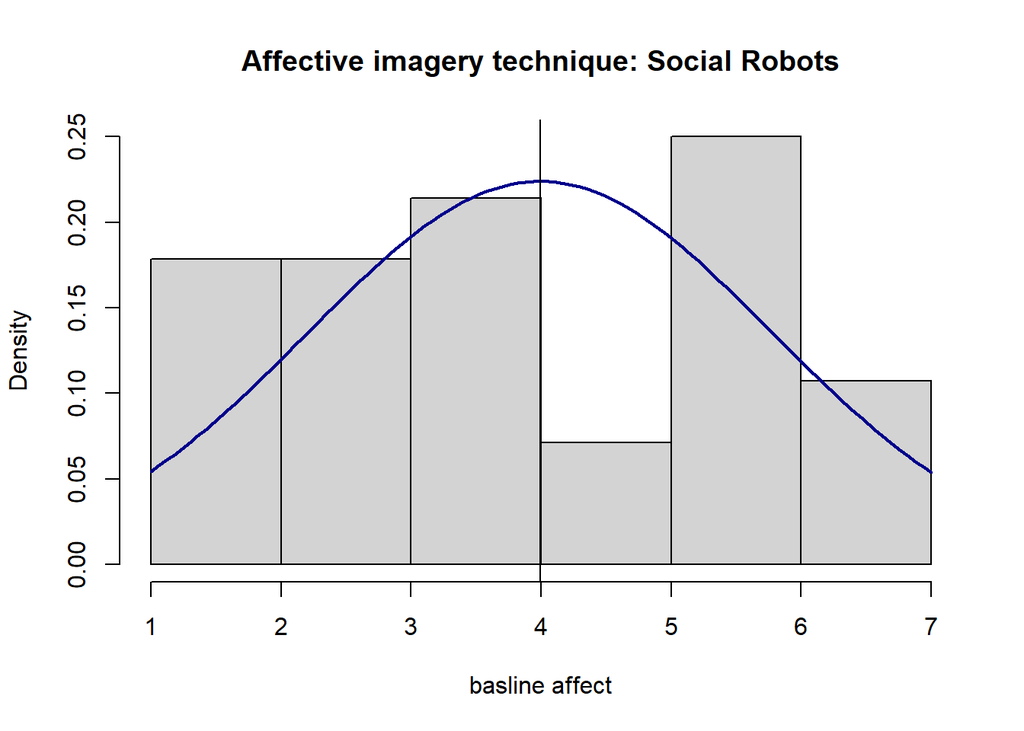

**Question (cognitive component)** adapted from De Deyne, Navarro, Perfors, Brysbaert, & Storms, 2019, and Cousse, Trutnevyte, & Hahnel, 2021:

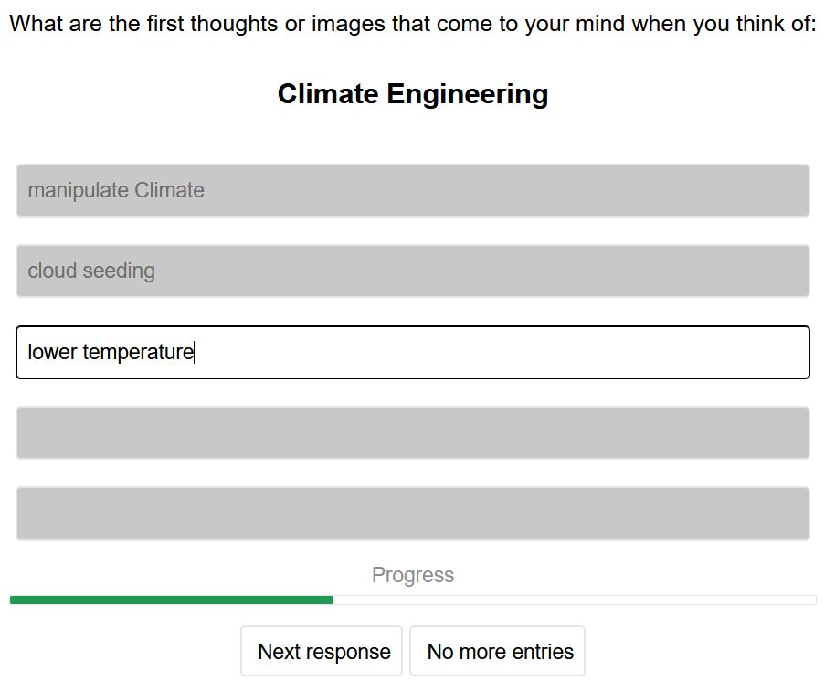

**Question (affective component)**:

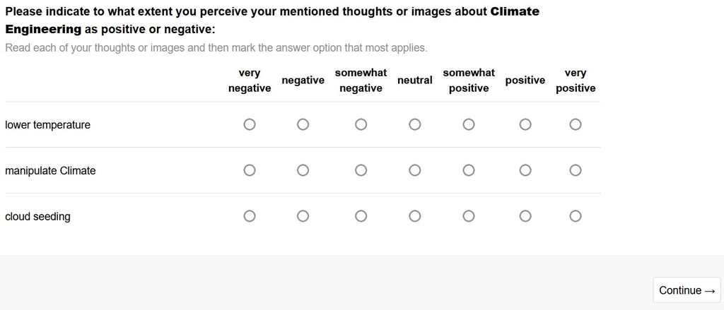